# EDA of Red Wines quality by Oleksandr Brazhenko

```r
# Load all of the packages that you end up using
# in your analysis in this code chunk.
library(ggplot2)
library(lsr)
library(GGally)
library(RColorBrewer)
library(grid)
library(gridExtra)
library(ellipse)
library(MASS)
library(ellipse)
library(lattice)
library(memisc)
library(reshape2)
library(scales)
#function to create hist object
plot_hist_one_var <- function(x_str = "fixed.acidity", t, xl) {
  ggplot( data = rw, aes_string(x = x_str)) +
    geom_histogram(color="white", fill="#3366FF")+
    ggtitle(t)+
    xlab(xl)+
    theme(plot.title = element_text(size=12))
}

#function to create box plot object
box_plot_func <- function(x_str = "quality.rank",
                          y_str, xl = "Quality rank",yl,t){
  ggplot( data = rw, aes_string(x=x_str, y = y_str)) +
    geom_boxplot()+
    xlab(xl)+
    ylab(yl)+
    ggtitle(t)
}

#function to create sactterplot object
point_plot_func <- function( col = "quality.rank",
                            x_str, y_str, xl, yl, t, rvrs = T,
                            lt = "Quality rank" ){
  ggplot( data = rw, aes_string(x=x_str, y = y_str, color=col)) +
    geom_point(size=3, alpha=0.5, position="jitter")+
    xlab(xl)+
    ylab(yl)+
    ggtitle(t)+
    scale_color_brewer(palette="Spectral",
                       guide = guide_legend(title = lt,
                                            reverse = rvrs))
}

#function to create density plot object
density_plot_func <- function(d = rw,x_str,col,xl,t){
  ggplot( data = d, aes_string(x = x_str, color=col ))+
    geom_density(size = 1)+
    xlab(xl)+
    ggtitle(t)
}
```

# Analysis

Main purpose of this data set analysis is figure out which chemical chracteristics have influence on red wine quality.

Explore the following parameters:

- fixed acidity (tartaric acid - g / dm^3)
- volatile acidity (acetic acid - g / dm^3)
- citric acid (g / dm^3)
- residual sugar (g / dm^3)
- chlorides (sodium chloride - g / dm^3
- free sulfur dioxide (mg / dm^3)
- total sulfur dioxide (mg / dm^3)
- density (g / cm^3)
- pH
- sulphates (potassium sulphate - g / dm3)
- alcohol (% by volume)

Output variable (based on sensory data): * quality (score between 0 and 10)

## Load the Data

```r
rw <- read.csv('D:/courses/data/Project 3/final_project/wineQualityReds.csv',
               sep=',')
```

### Summary of the Data Set

```r
names(rw)
```

```
##  [1] "X"                    "fixed.acidity"        "volatile.acidity"
##  [4] "citric.acid"          "residual.sugar"       "chlorides"
##  [7] "free.sulfur.dioxide"  "total.sulfur.dioxide" "density"
## [10] "pH"                   "sulphates"            "alcohol"
## [13] "quality"
```

```r
summary(rw)
```

```
##        X          fixed.acidity   volatile.acidity  citric.acid
##  Min.   :   1.0   Min.   : 4.60   Min.   :0.1200   Min.   :0.000
##  1st Qu.: 400.5   1st Qu.: 7.10   1st Qu.:0.3900   1st Qu.:0.090
##  Median : 800.0   Median : 7.90   Median :0.5200   Median :0.260
##  Mean   : 800.0   Mean   : 8.32   Mean   :0.5278   Mean   :0.271
##  3rd Qu.:1199.5   3rd Qu.: 9.20   3rd Qu.:0.6400   3rd Qu.:0.420
##  Max.   :1599.0   Max.   :15.90   Max.   :1.5800   Max.   :1.000
##  residual.sugar     chlorides       free.sulfur.dioxide
##  Min.   : 0.900   Min.   :0.01200   Min.   : 1.00
##  1st Qu.: 1.900   1st Qu.:0.07000   1st Qu.: 7.00
##  Median : 2.200   Median :0.07900   Median :14.00
##  Mean   : 2.539   Mean   :0.08747   Mean   :15.87
##  3rd Qu.: 2.600   3rd Qu.:0.09000   3rd Qu.:21.00
##  Max.   :15.500   Max.   :0.61100   Max.   :72.00
##  total.sulfur.dioxide    density             pH          sulphates
##  Min.   :  6.00       Min.   :0.9901   Min.   :2.740   Min.   :0.3300
##  1st Qu.: 22.00       1st Qu.:0.9956   1st Qu.:3.210   1st Qu.:0.5500
##  Median : 38.00       Median :0.9968   Median :3.310   Median :0.6200
##  Mean   : 46.47       Mean   :0.9967   Mean   :3.311   Mean   :0.6581
##  3rd Qu.: 62.00       3rd Qu.:0.9978   3rd Qu.:3.400   3rd Qu.:0.7300
##  Max.   :289.00       Max.   :1.0037   Max.   :4.010   Max.   :2.0000
##     alcohol         quality
##  Min.   : 8.40   Min.   :3.000
##  1st Qu.: 9.50   1st Qu.:5.000
##  Median :10.20   Median :6.000
##  Mean   :10.42   Mean   :5.636
##  3rd Qu.:11.10   3rd Qu.:6.000
##  Max.   :14.90   Max.   :8.000
```

#### Observations from the Summary

- Residual sugar maximum value is 15.5 g / dm^3. So, there are no sweet wines in this data set
- Huge dispersion of Total SO2 from 6 to 289.
- alcohol varies from 8.4 to 14.9 %
- pH range 2.74 - 4.0
- quality minimum value is 3 and maximum is 8

## Understanding the individual variables in the data set

#### New categorical variable

```r
rw$quality.rank <- cut(rw$quality, c(3,4,6,10), labels = c("low","middle","high"), include.lowest = T)

summary(rw$quality.rank)
```

```
##    low middle   high
##     63   1319    217
```

```r
#convert quality variable into categorical variable
rw$quality <- factor(rw$quality)
```

#### Quality distribution

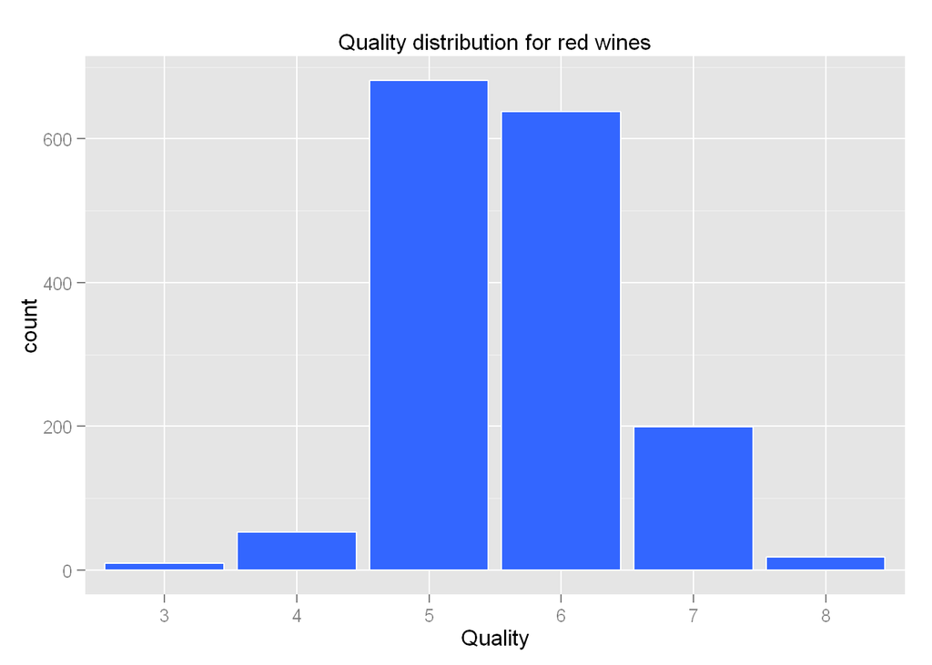

```r
plot_hist_one_var(t = "Quality distribution for red wines",
                                  x_str = "quality",
                                  xl = "Quality")
```

## Understanding the distribution of single variables

```
## stat_bin: binwidth defaulted to range/30. Use 'binwidth = x' to adjust this.
## stat_bin: binwidth defaulted to range/30. Use 'binwidth = x' to adjust this.
## stat_bin: binwidth defaulted to range/30. Use 'binwidth = x' to adjust this.
## stat_bin: binwidth defaulted to range/30. Use 'binwidth = x' to adjust this.
```

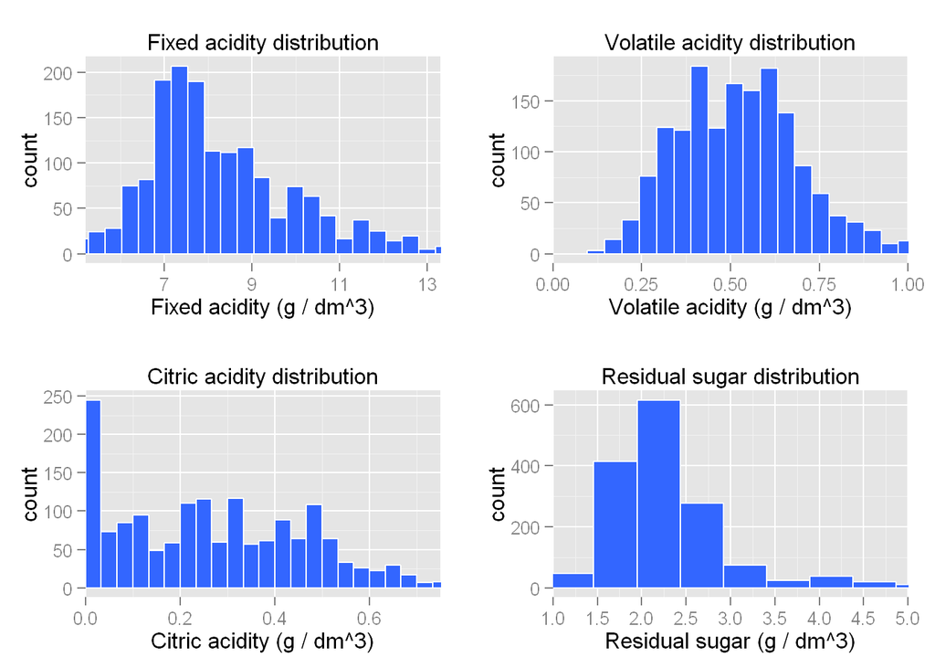

```r
plot_fix_acid = plot_hist_one_var(t = "Fixed acidity distribution",
                                  x_str = "fixed.acidity",
                                  xl = "Fixed acidity (g / dm^3)")+
  coord_cartesian(xlim=c(quantile(rw$fixed.acidity, 0.01),
                         quantile(rw$fixed.acidity, 0.99)))

plot_vol_acid = plot_hist_one_var(x_str = "volatile.acidity",
                          t = "Volatile acidity distribution",
                          xl = "Volatile acidity (g / dm^3)") +
                     coord_cartesian(xlim=c(0,1))

plot_cit_acid = plot_hist_one_var(x_str = "citric.acid",
                          t = "Citric acidity distribution",
                          xl = "Citric acidity (g / dm^3)") +
                     coord_cartesian(xlim=c(0,0.75))

plot_res_sugar = plot_hist_one_var(x_str = "residual.sugar",
                          t = "Residual sugar distribution",
                          xl = "Residual sugar (g / dm^3)") +
                     scale_x_continuous(breaks = seq(1,5,0.5))+
                     coord_cartesian(xlim=c(1,5))

plot_chlorides = plot_hist_one_var(x_str = "chlorides",
                          t = "Chlorides distribution",
                          xl = "Chlorides (g / dm^3)") +
                     coord_cartesian(xlim=c(0,0.2))

plot_so2 = plot_hist_one_var(x_str = "total.sulfur.dioxide",
                          t = "Total sulfur dioxide distribution",
                          xl = "Total sulfur dioxide (mg / dm^3)") +
                      coord_cartesian(xlim=c(0,150))

plot_ph = plot_hist_one_var(x_str = "pH",
                          t = "pH distribution",
                          xl = "pH") +
                      scale_x_continuous(breaks = seq(0,4,0.2))+
                      coord_cartesian(xlim=c(2.8,3.8))

plot_alcohol = plot_hist_one_var(x_str = "alcohol",
                          t = "Alcohol distributionn",
                          xl = "Alcohol (% by volume)")

grid.arrange(plot_fix_acid,plot_vol_acid,plot_cit_acid,plot_res_sugar,ncol=2)
```

```
## stat_bin: binwidth defaulted to range/30. Use 'binwidth = x' to adjust this.
## stat_bin: binwidth defaulted to range/30. Use 'binwidth = x' to adjust this.
## stat_bin: binwidth defaulted to range/30. Use 'binwidth = x' to adjust this.
## stat_bin: binwidth defaulted to range/30. Use 'binwidth = x' to adjust this.
```

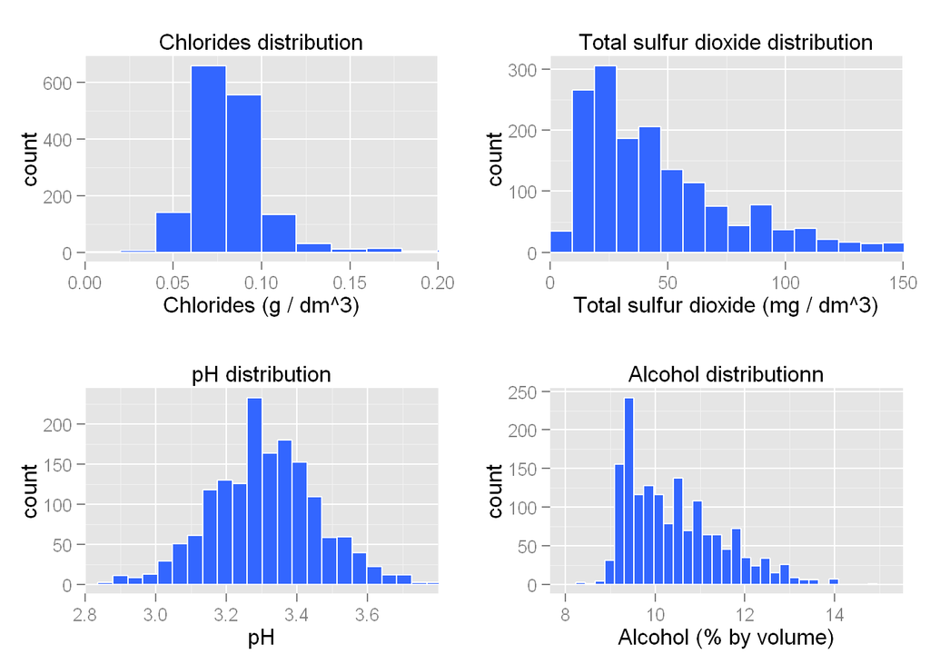

```r
grid.arrange(plot_chlorides,plot_so2,plot_ph,plot_alcohol,ncol=2)
```

## Understanding of two variables relations

### Correlation between variables

```r
correlate(rw)
```

```
##
## CORRELATIONS
## ============
## - correlation type:  pearson
## - correlations shown only when both variables are numeric
##
##                           X fixed.acidity volatile.acidity citric.acid
## X                         .        -0.268           -0.009      -0.154
## fixed.acidity        -0.268             .           -0.256       0.672
## volatile.acidity     -0.009        -0.256                .      -0.552
## citric.acid          -0.154         0.672           -0.552           .
## residual.sugar       -0.031         0.115            0.002       0.144
## chlorides            -0.120         0.094            0.061       0.204
## free.sulfur.dioxide   0.090        -0.154           -0.011      -0.061
## total.sulfur.dioxide -0.118        -0.113            0.076       0.036
## density              -0.368         0.668            0.022       0.365
## pH                    0.136        -0.683            0.235      -0.542
## sulphates            -0.125         0.183           -0.261       0.313
## alcohol               0.245        -0.062           -0.202       0.110
## quality                   .             .                .           .
## quality.rank              .             .                .           .
##                      residual.sugar chlorides free.sulfur.dioxide
## X                            -0.031    -0.120               0.090
## fixed.acidity                 0.115     0.094              -0.154
## volatile.acidity              0.002     0.061              -0.011
## citric.acid                   0.144     0.204              -0.061
## residual.sugar                    .     0.056               0.187
## chlorides                     0.056         .               0.006
## free.sulfur.dioxide           0.187     0.006                   .
## total.sulfur.dioxide          0.203     0.047               0.668
## density                       0.355     0.201              -0.022
## pH                           -0.086    -0.265               0.070
## sulphates                     0.006     0.371               0.052
## alcohol                       0.042    -0.221              -0.069
## quality                           .         .                   .
## quality.rank                      .         .                   .
##                      total.sulfur.dioxide density     pH sulphates alcohol
## X                                  -0.118  -0.368  0.136    -0.125   0.245
## fixed.acidity                      -0.113   0.668 -0.683     0.183  -0.062
## volatile.acidity                    0.076   0.022  0.235    -0.261  -0.202
```

[output cut: 11 more lines]

```
##                      quality quality.rank
## X                          .            .
## fixed.acidity              .            .
## volatile.acidity           .            .
## citric.acid                .            .
## residual.sugar             .            .
## chlorides                  .            .
## free.sulfur.dioxide        .            .
## total.sulfur.dioxide       .            .
## density                    .            .
## pH                         .            .
## sulphates                  .            .
## alcohol                    .            .
## quality                    .            .
## quality.rank               .            .
```

#### Correlation plot

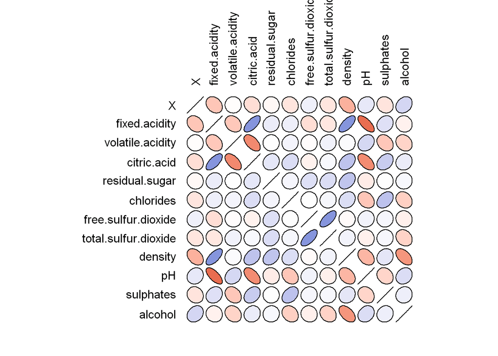

```r
#craete new dataframe without categorical vars
numeric_vars <- names(rw) %in% c("quality.rank", "quality")
rw_num <- rw[!numeric_vars]
ctab <- cor(rw_num)
#plot which show correlation in more convenient way
colorfun <- colorRamp(c("#CC0000","white","#3366CC"), space="Lab")
plotcorr(ctab, mar = c(0,0,0,0), col=rgb(colorfun((ctab+1)/2),
                                         maxColorValue=255))
```

#### ggpairs function

[output not shown]

[output not shown]

[output not shown]

[output not shown]

[output not shown]

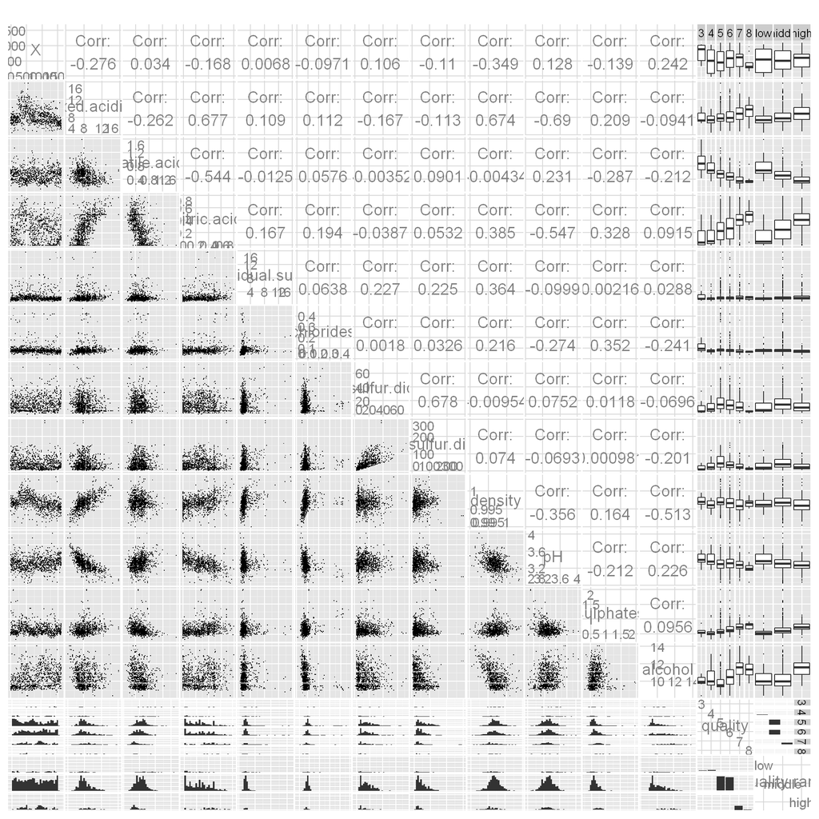

```r
set.seed(278812)
rw_samp <- rw[sample(1:length(rw$quality), 1000), ]
ggpairs(rw_samp, axisLabels = "internal",
        params = c(shape = I('.'), outlier.shape = I('.')),
        diag = list(prams = c(size = 1)))
```

### Variables by quality ranking

#### Citric acid by quality rank

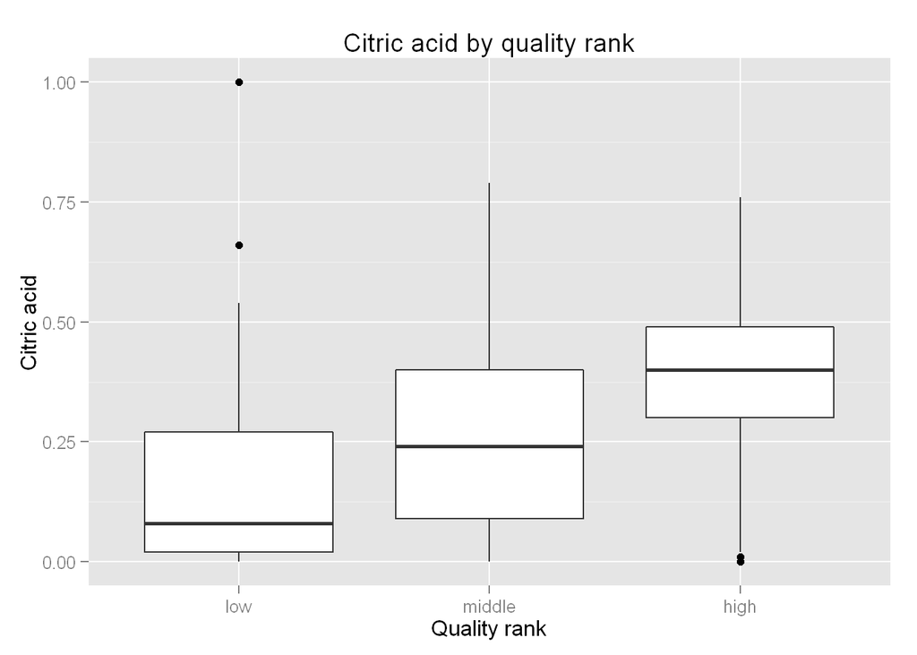

```r
box_plot_func(y_str = "citric.acid",
              yl = "Citric acid",
              t = "Citric acid by quality rank")
```

Quality wines have higher level of Citric acid. At the same time max value not bigger than 1.0 and 3rd quartile equal to 0.42. Outliers almost absent.

#### SO2 by quality rank

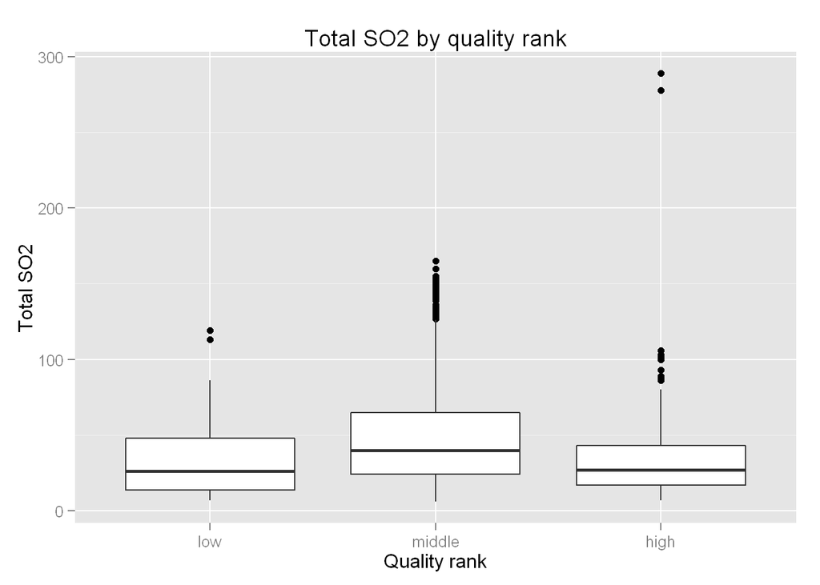

```r
box_plot_func(y_str = "total.sulfur.dioxide",
              yl = "Total SO2",
              t = "Total SO2 by quality rank")
```

No conclusions from Total SO2 distribution. Maybe, the reason is the values lie under the obvious limits in most of observations.

#### Residual sugar by quality rank

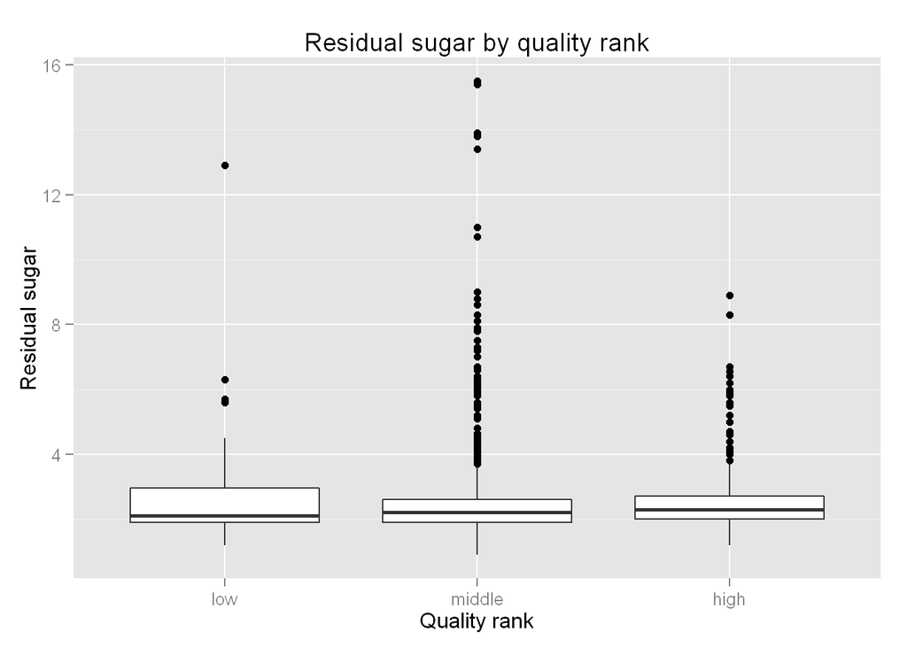

```r
box_plot_func(y_str = "residual.sugar",
              yl = "Residual sugar",
              t = "Residual sugar by quality rank")
```

Set limits and zoom the plot

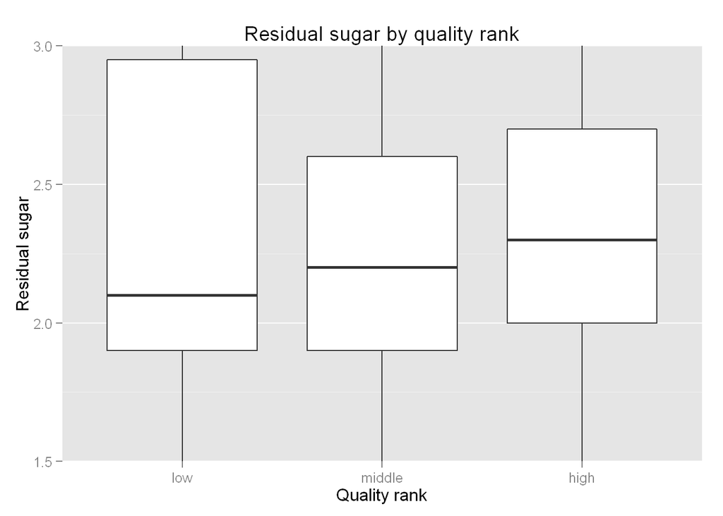

```r
box_plot_func(y_str = "residual.sugar",
              yl = "Residual sugar",
              t = "Residual sugar by quality rank")+
  coord_cartesian(ylim=c(1.5,3))
```

```r
by(rw$residual.sugar, rw$quality.rank,  summary)
```

```
## rw$quality.rank: low
##    Min. 1st Qu.  Median    Mean 3rd Qu.    Max.
##   1.200   1.900   2.100   2.685   2.950  12.900
## --------------------------------------------------------
## rw$quality.rank: middle
##    Min. 1st Qu.  Median    Mean 3rd Qu.    Max.
##   0.900   1.900   2.200   2.504   2.600  15.500
## --------------------------------------------------------
## rw$quality.rank: high
##    Min. 1st Qu.  Median    Mean 3rd Qu.    Max.
##   1.200   2.000   2.300   2.709   2.700   8.900
```

#### pH by quality rank

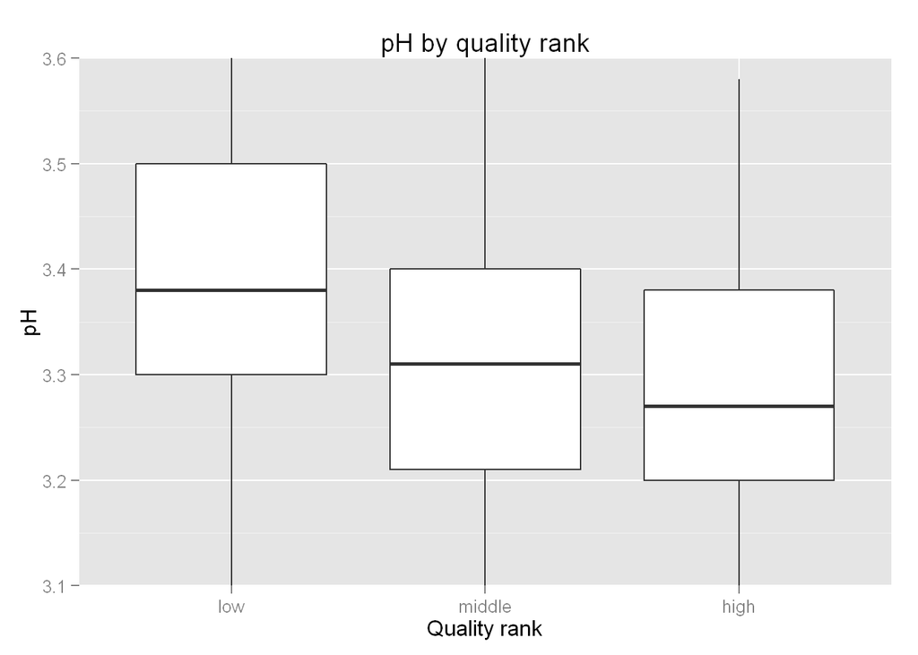

```r
box_plot_func(y_str = "pH",
              yl = "pH",
              t = "pH by quality rank")+
  coord_cartesian(ylim=c(3.1,3.6))
```

```r
by(rw$pH, rw$quality.rank,  summary)
```

```
## rw$quality.rank: low
##    Min. 1st Qu.  Median    Mean 3rd Qu.    Max.
##   2.740   3.300   3.380   3.384   3.500   3.900
## --------------------------------------------------------
## rw$quality.rank: middle
##    Min. 1st Qu.  Median    Mean 3rd Qu.    Max.
##   2.860   3.210   3.310   3.311   3.400   4.010
## --------------------------------------------------------
## rw$quality.rank: high
##    Min. 1st Qu.  Median    Mean 3rd Qu.    Max.
##   2.880   3.200   3.270   3.289   3.380   3.780
```

pH has higher values for poor wines.

#### Alcohol by quality rank

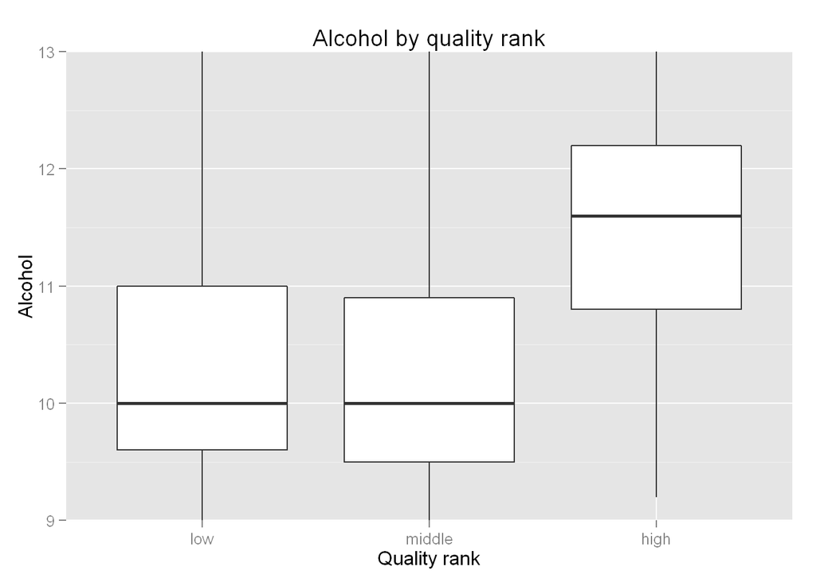

```r
box_plot_func(y_str = "alcohol",
              yl = "Alcohol",
              t = "Alcohol by quality rank")+
    coord_cartesian(ylim=c(9,13))
```

```r
by(rw$alcohol, rw$quality.rank,  summary)
```

```
## rw$quality.rank: low
##    Min. 1st Qu.  Median    Mean 3rd Qu.    Max.
##    8.40    9.60   10.00   10.22   11.00   13.10
## --------------------------------------------------------
## rw$quality.rank: middle
##    Min. 1st Qu.  Median    Mean 3rd Qu.    Max.
##    8.40    9.50   10.00   10.25   10.90   14.90
## --------------------------------------------------------
## rw$quality.rank: high
##    Min. 1st Qu.  Median    Mean 3rd Qu.    Max.
##    9.20   10.80   11.60   11.52   12.20   14.00
```

Significant difference of alcohol value between “high” quality wines and the others. At the same time, wine with “low” and “middle” quality rank have distribution and median pretty similar.

#### Sulphates by quality rank

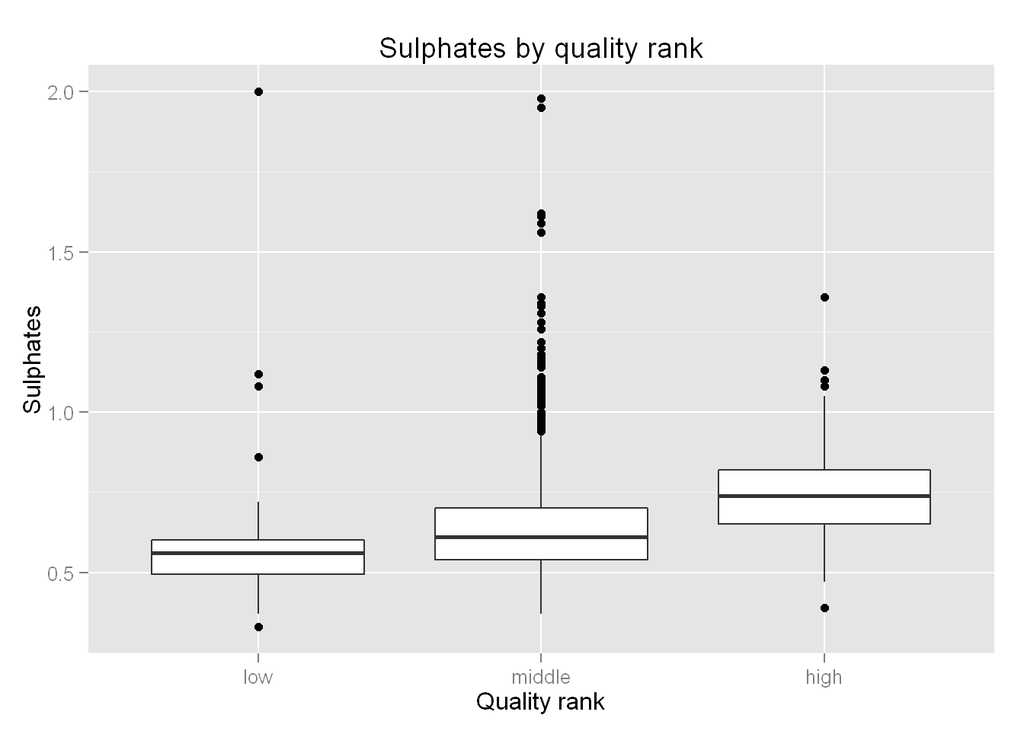

```r
box_plot_func(y_str = "sulphates",
              yl = "Sulphates",
              t = "Sulphates by quality rank")
```

Set limits and zoom the plot

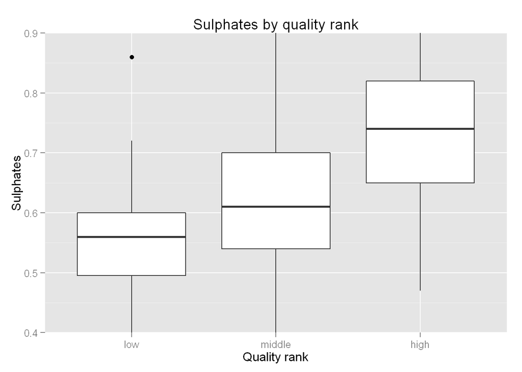

```r
box_plot_func(y_str = "sulphates",
              yl = "Sulphates",
              t = "Sulphates by quality rank")+
  coord_cartesian(ylim=c(0.4,0.9))
```

```r
by(rw$sulphates, rw$quality.rank,  summary)
```

```
## rw$quality.rank: low
##    Min. 1st Qu.  Median    Mean 3rd Qu.    Max.
##  0.3300  0.4950  0.5600  0.5922  0.6000  2.0000
## --------------------------------------------------------
## rw$quality.rank: middle
##    Min. 1st Qu.  Median    Mean 3rd Qu.    Max.
##  0.3700  0.5400  0.6100  0.6473  0.7000  1.9800
## --------------------------------------------------------
## rw$quality.rank: high
##    Min. 1st Qu.  Median    Mean 3rd Qu.    Max.
##  0.3900  0.6500  0.7400  0.7435  0.8200  1.3600
```

There are unexpected result a little bit. Quality rank depends on sulphates value. I’d assumed sulphates makes wine worst, but in this case it isn’t confirmed. Examine this value later.

#### Chlorides by quality rank

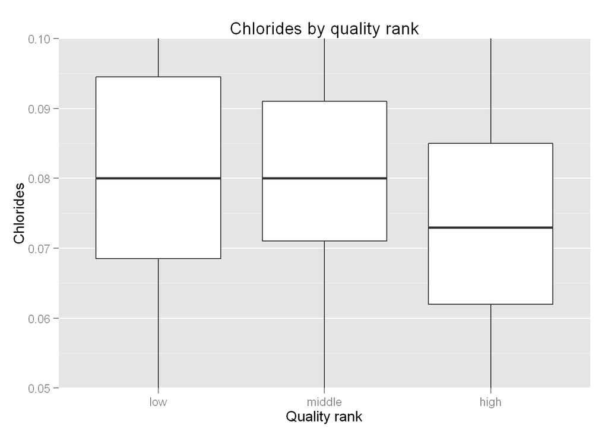

```r
box_plot_func(y_str = "chlorides",
              yl = "Chlorides",
              t = "Chlorides by quality rank")+
  coord_cartesian(ylim=c(0.05,0.1))
```

Chlorides have many outliers.

#### Observations from two variables exploration

Seems that wines quality depend on the following characteristics:

- alcohol;
- sulphates;
- Volatile acidity;
- Citric acid

Let’s examine these variables deeper.

## Explore many variables

### Examine pH more closely

#### Chlorides vs pH by Quality rank

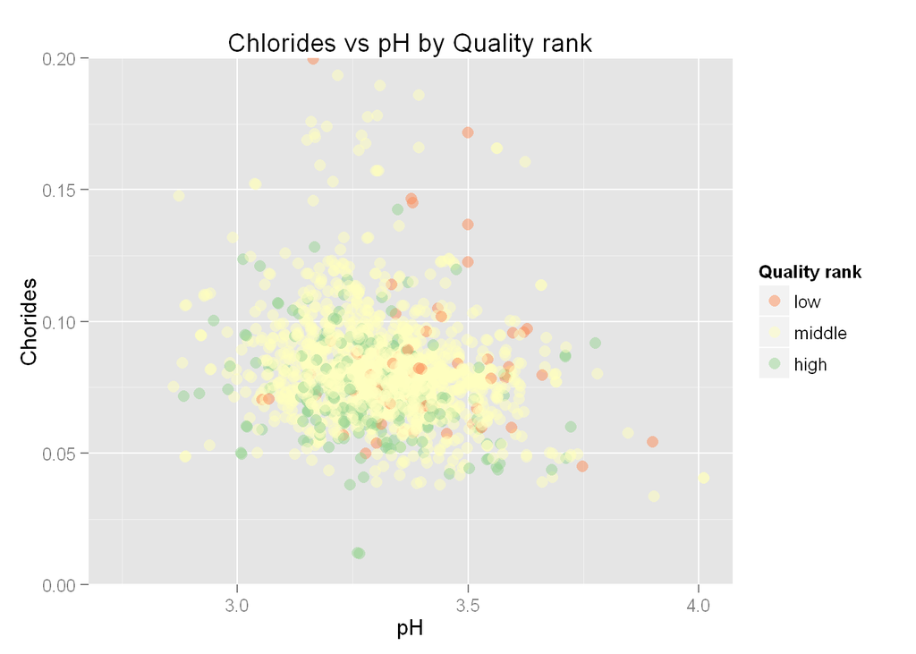

```r
point_plot_func( x_str = "pH",
                 y_str = "chlorides",
                 xl = "pH",
                 yl = "Chorides",
                 t = "Chlorides vs pH by Quality rank",
                 rvrs = F)+
  coord_cartesian(ylim=c(0,0.2))
```

No conclusions from this plot

#### Sulphates vs pH by Quality rank

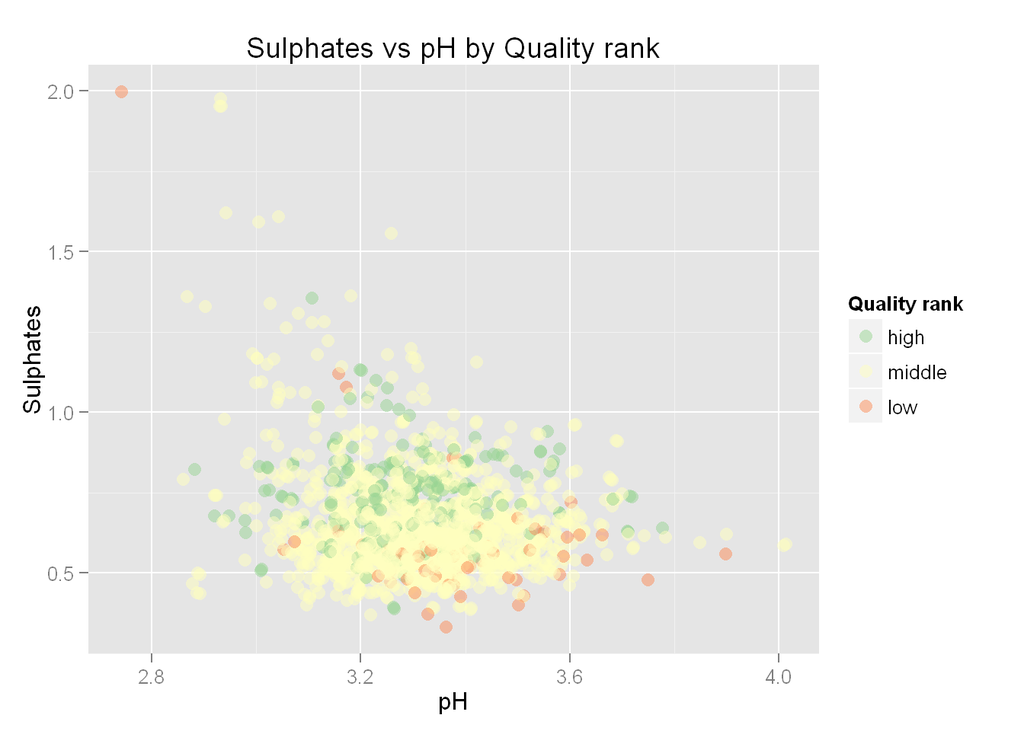

```r
point_plot_func( x_str = "pH",
                 y_str = "sulphates",
                 xl = "pH",
                 yl = "Sulphates",
                 t = "Sulphates vs pH by Quality rank")
```

It looks like wines with higher sulphates value will be more quality with the equal level of pH. One more evidence of sulphates influence on quality.

#### Citric acid vs pH by Quality rank

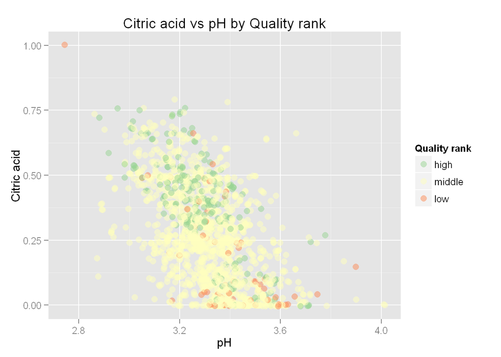

```r
point_plot_func( x_str = "pH",
                 y_str = "citric.acid",
                 xl = "pH",
                 yl = "Citric acid",
                 t = "Citric acid vs pH by Quality rank")
```

Most of HQ wines lie above 0.25 of Citric acid value

#### Volatile acidity vs pH by Quality rank

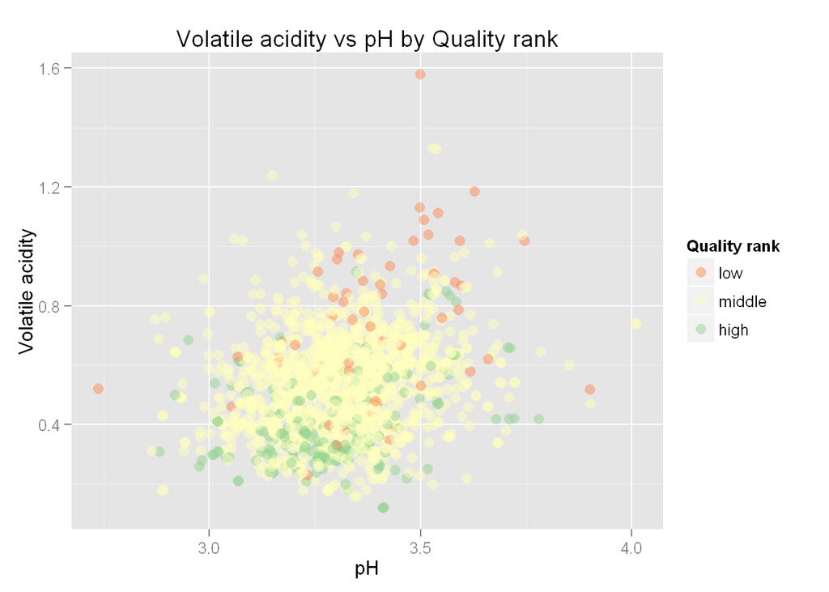

```r
point_plot_func( x_str = "pH",
                 y_str = "volatile.acidity",
                 xl = "pH",
                 yl = "Volatile acidity",
                 t = "Volatile acidity vs pH by Quality rank",
                 rvrs = F)
```

Looks like wines with lower volatile acidity value will be of higher quality with the equal level of pH.

### Examine sulphates more closely

#### Sulphates vs SO2 by Quality rank

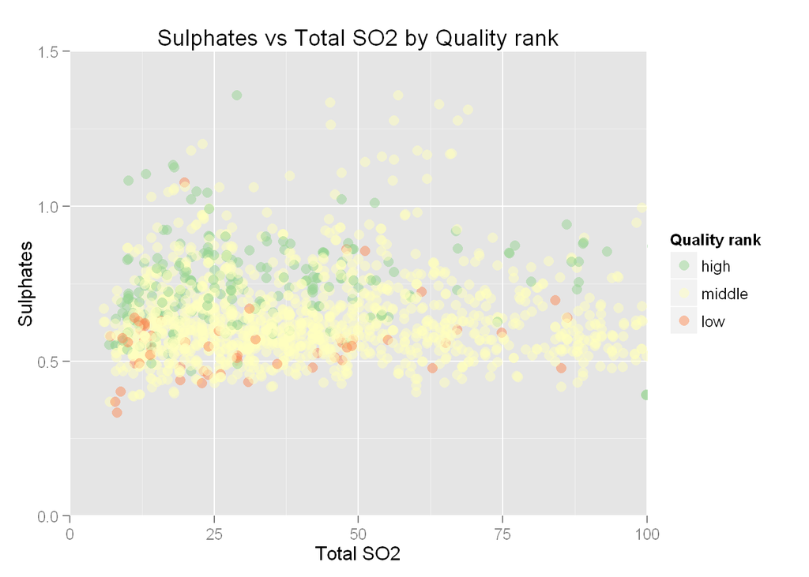

```r
point_plot_func( x_str = "total.sulfur.dioxide",
                 y_str = "sulphates",
                 xl = "Total SO2",
                 yl = "Sulphates",
                 t = "Sulphates vs Total SO2 by Quality rank")+
    coord_cartesian(ylim=c(0,1.5), xlim=c(0,100))
```

Another confirmation of sulphates influence. Seems like quality wines mostly consists no more than 50g of total SO2.

#### Sulphates vs volatile acidity by Quality rank

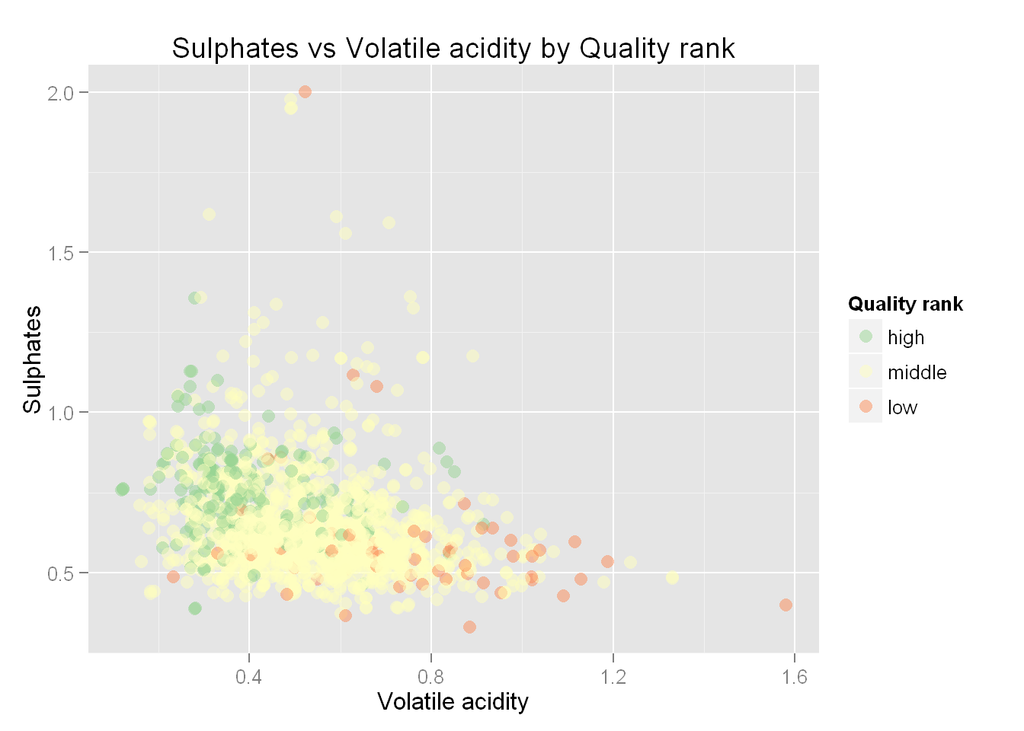

```r
point_plot_func( x_str = "volatile.acidity",
                 y_str = "sulphates",
                 xl = "Volatile acidity",
                 yl = "Sulphates",
                 t = "Sulphates vs Volatile acidity by Quality rank")
```

#### Sulphates vs alcohol by Quality rank

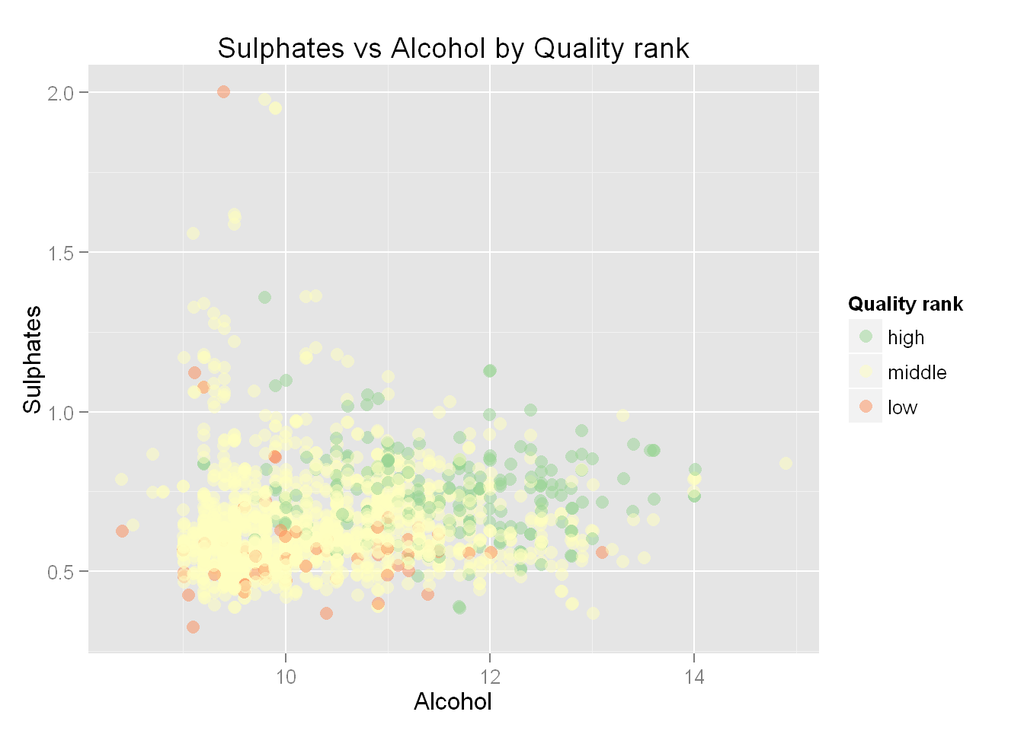

```r
point_plot_func( x_str = "alcohol",
                 y_str = "sulphates",
                 xl = "Alcohol",
                 yl = "Sulphates",
                 t = "Sulphates vs Alcohol by Quality rank")
```

### Examine alcohol more closely

#### Density vs alcohol by Quality rank

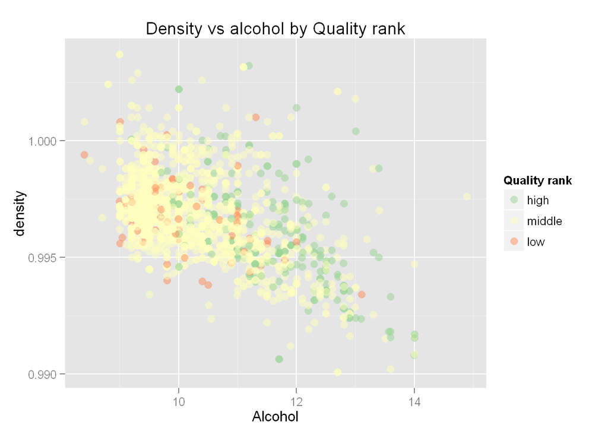

```r
point_plot_func( x_str = "alcohol",
                 y_str = "density",
                 xl = "Alcohol",
                 yl = "density",
                 t = "Density vs alcohol by Quality rank")
```

Looks like density reduced in dependence on alcohol level growth

#### Density vs residual sugar by Quality rank

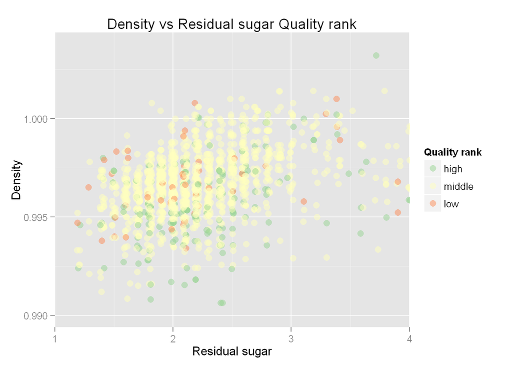

```r
point_plot_func( x_str = "residual.sugar",
                 y_str = "density",
                 xl = "Residual sugar",
                 yl = "Density",
                 t = "Density vs Residual sugar Quality rank")+
  coord_cartesian(xlim=c(1,4))
```

No conclusions from this plot

#### Residual sugar vs Alcohol by Density

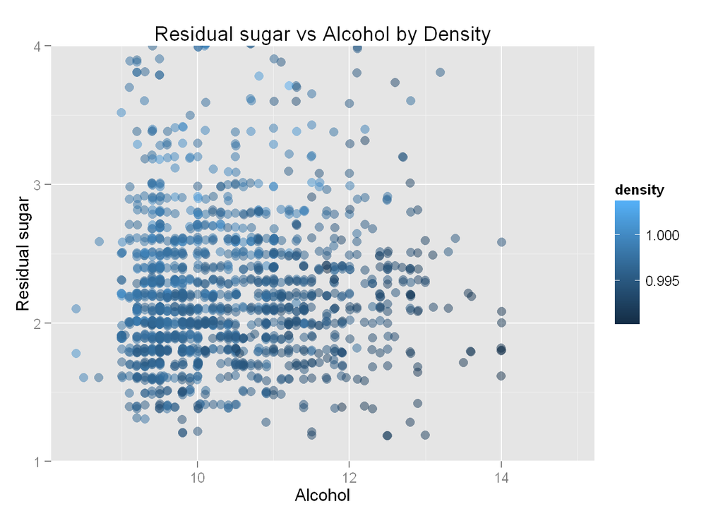

```r
ggplot( data = rw, aes(x=alcohol, y = residual.sugar, color=density)) +
  geom_point(size=3, alpha=0.5, position="jitter")+
  xlab("Alcohol")+
  ylab("Residual sugar")+
  ggtitle("Residual sugar vs Alcohol by Density")+
  coord_cartesian(ylim=c(1,4))
```

No conclusions from this plot

#### Residual sugar vs Alcohol by Quality rank

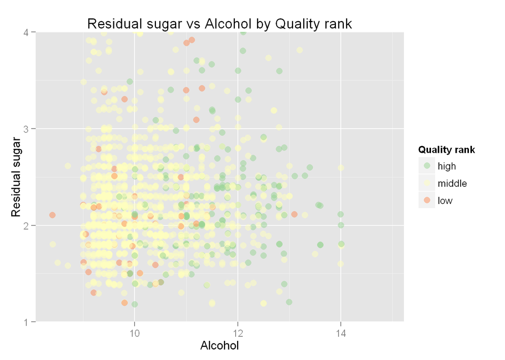

```r
point_plot_func( x_str = "alcohol",
                 y_str = "residual.sugar",
                 yl = "Residual sugar",
                 xl = "Alcohol",
                 t = "Residual sugar vs Alcohol by Quality rank")+
  coord_cartesian(ylim=c(1,4))
```

No conclusions from this plot

#### Citric acid vs alcohol by Quality rank

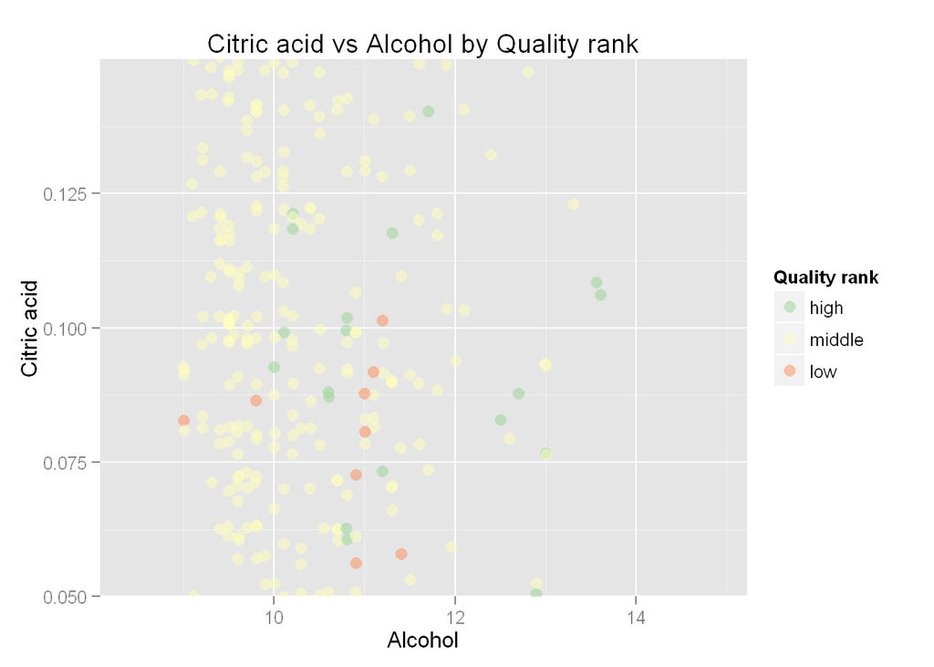

```r
point_plot_func( x_str = "alcohol",
                 y_str = "citric.acid",
                 yl = "Citric acid",
                 xl = "Alcohol",
                 t = "Citric acid vs Alcohol by Quality rank")+
  coord_cartesian(ylim=c(0.05,0.15))
```

No conclusions from this plot

#### Volatile acidity vs alcohol by Quality rank

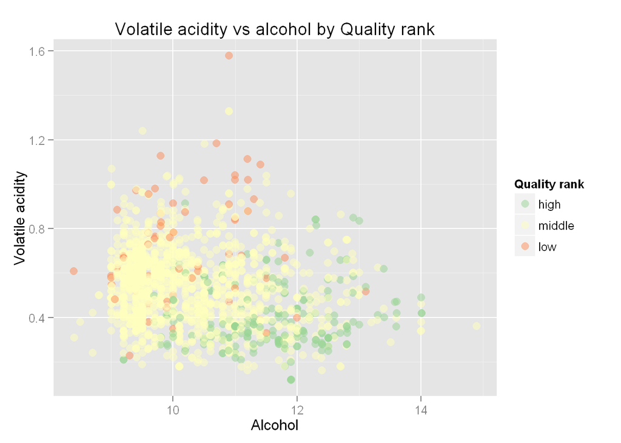

```r
point_plot_func( x_str = "alcohol",
                 y_str = "volatile.acidity",
                 yl = "Volatile acidity",
                 xl = "Alcohol",
                 t = "Volatile acidity vs alcohol by Quality rank")
```

There are confirmed thesis wines more quality with lower volatile acidity level.

## Additional analysis of high quality wines

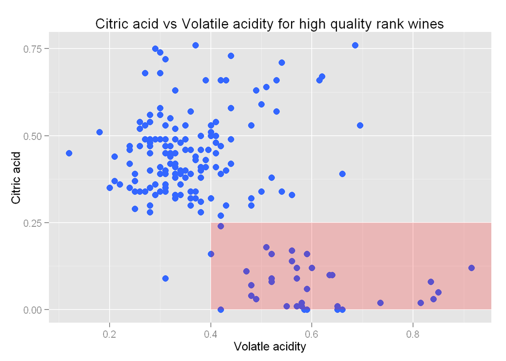

```r
#craete subset with only HQ rank wines
hqrw = subset(rw, quality.rank == "high")

ggplot()+
  geom_point(data = hqrw, aes(x=volatile.acidity,
                              y = citric.acid),
             color = "#3366FF",
             size=3)+
  ylab("Citric acid")+
  xlab("Volatle acidity")+
  ggtitle("Citric acid vs Volatile acidity for high quality rank wines")+
  scale_x_continuous(breaks = seq(0,1.6,0.2))+
  scale_y_continuous(breaks = seq(0,0.75,0.25))+
  geom_rect(aes(xmin=0.4,xmax=Inf,ymin=0,ymax=0.25),alpha=0.2,fill="red")
```

This plot show mostly of HQ wines placed in zone with high level of citric acid (>0.25) and low level of volatile acidity (<0.4). However, there are some HQ wines which break this rule. They placed in red square on the plot.

I’d like to compare these two data sets and try to figure out which parameters are distinguished and which characteristics contribute to save high quality of wine even in case of high volatile acidity and low citric acid. Create new categorical variable in new data set. It’ll be defined whether wine lie in “red zone” or not. Let’s call it hqrw$is.outliers

```r
hqrw$is.outliers <- ifelse(hqrw$citric.acid<0.25 & hqrw$volatile.acidity>0.4,
                        "y", "n")
```

Let’s look at our variables

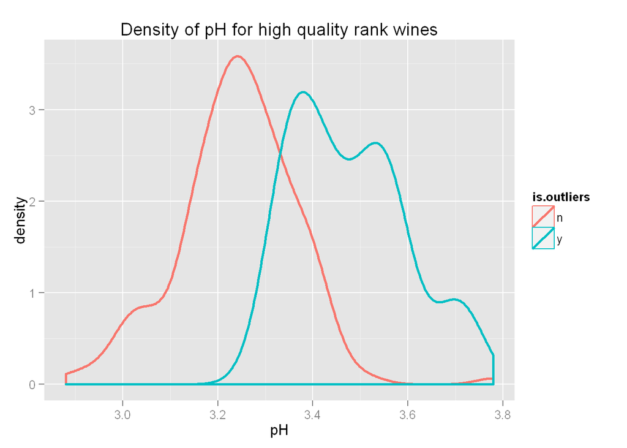

```r
density_plot_func(d = hqrw,
                  col = "is.outliers",
                  x_str = "pH",
                  xl = "pH",
                  t = "Density of pH for high quality rank wines")
```

```r
by(hqrw$pH, hqrw$is.outliers,  summary)
```

```
## hqrw$is.outliers: n
##    Min. 1st Qu.  Median    Mean 3rd Qu.    Max.
##   2.880   3.170   3.240   3.241   3.320   3.780
## --------------------------------------------------------
## hqrw$is.outliers: y
##    Min. 1st Qu.  Median    Mean 3rd Qu.    Max.
##   3.320   3.370   3.460   3.476   3.560   3.720
```

pH level significantly differ between these two groups. 1st Qu. of “red zones” values equal to 3.37. It’s higher than the 3rd Qu. (3.32) of the other part of data set. Before I noticed worse wines has higher pH value. In this case HQ wines have higher level of pH. So, it’s very interesting finding.

Let’s look on the other variables.

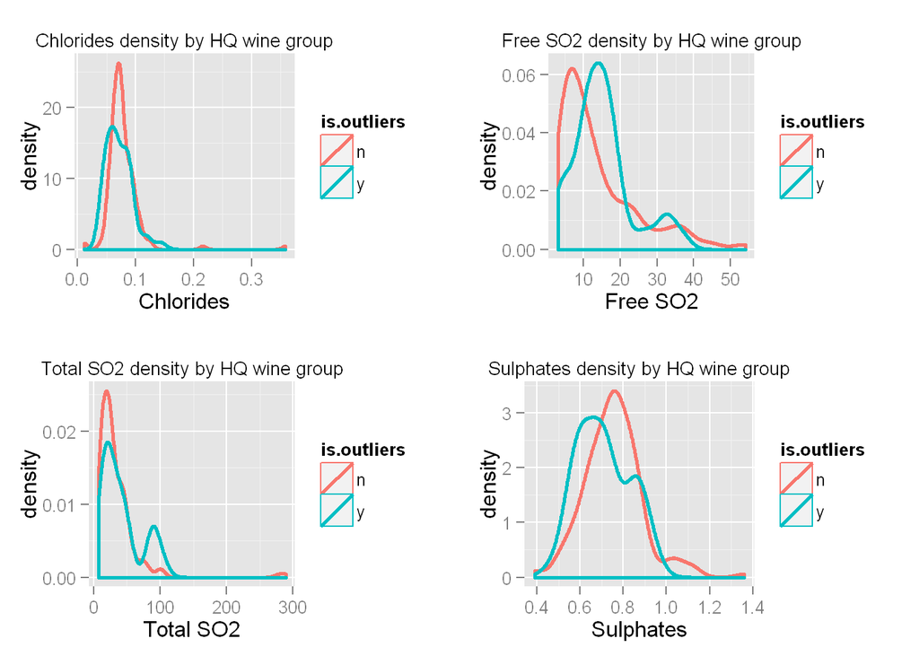

```r
HQ_sulph_density = density_plot_func(d = hqrw,
                  col = "is.outliers",
                  x_str = "sulphates",
                  xl = "Sulphates",
                  t = "Sulphates density by HQ wine group")+
            theme(plot.title = element_text(size=10))

HQ_totalso_density = density_plot_func(d = hqrw,
                  col = "is.outliers",
                  x_str = "total.sulfur.dioxide",
                  xl = "Total SO2",
                  t = "Total SO2 density by HQ wine group")+
            theme(plot.title = element_text(size=10))

HQ_freeso_density = density_plot_func(d = hqrw,
                  col = "is.outliers",
                  x_str = "free.sulfur.dioxide",
                  xl = "Free SO2",
                  t = "Free SO2 density by HQ wine group")+
            theme(plot.title = element_text(size=10))

HQ_chlorides_density = density_plot_func(d = hqrw,
                  col = "is.outliers",
                  x_str = "chlorides",
                  xl = "Chlorides",
                  t = "Chlorides density by HQ wine group")+
            theme(plot.title = element_text(size=10))

grid.arrange(HQ_chlorides_density,
             HQ_freeso_density,
             HQ_totalso_density,
             HQ_sulph_density,
             ncol=2)
```

```r
by(hqrw$total.sulfur.dioxide, hqrw$is.outliers,  summary)
```

```
## hqrw$is.outliers: n
##    Min. 1st Qu.  Median    Mean 3rd Qu.    Max.
##    7.00   16.00   25.00   33.31   42.00  289.00
## --------------------------------------------------------
## hqrw$is.outliers: y
##    Min. 1st Qu.  Median    Mean 3rd Qu.    Max.
##   11.00   18.00   33.00   41.11   49.25  106.00
```

```r
by(hqrw$free.sulfur.dioxide, hqrw$is.outliers,  summary)
```

```
## hqrw$is.outliers: n
##    Min. 1st Qu.  Median    Mean 3rd Qu.    Max.
##    3.00    6.00   10.00   13.73   18.00   54.00
## --------------------------------------------------------
## hqrw$is.outliers: y
##    Min. 1st Qu.  Median    Mean 3rd Qu.    Max.
##    3.00   10.00   13.50   14.98   17.25   37.00
```

```r
by(hqrw$chlorides, hqrw$is.outliers,  summary)
```

```
## hqrw$is.outliers: n
##    Min. 1st Qu.  Median    Mean 3rd Qu.    Max.
## 0.01200 0.06300 0.07400 0.07714 0.08500 0.35800
## --------------------------------------------------------
## hqrw$is.outliers: y
##    Min. 1st Qu.  Median    Mean 3rd Qu.    Max.
## 0.04200 0.05400 0.06500 0.07109 0.08700 0.14300
```

# Final Plots and Summary

### Plot One

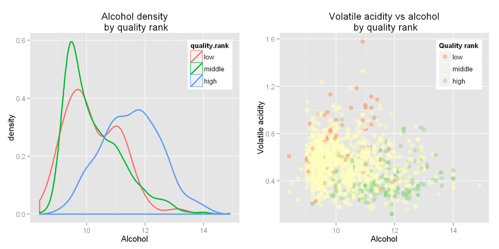

```r
final_plot_one_1 = density_plot_func(col = "quality.rank",
                  x_str = "alcohol",
                  xl = "Alcohol",
                  t = "Alcohol density\n by quality rank")+
  theme(legend.justification=c(1,1),
        legend.position=c(1,1))

final_plot_one_2 = point_plot_func( x_str = "alcohol",
                 y_str = "volatile.acidity",
                 yl = "Volatile acidity",
                 xl = "Alcohol",
                 t = "Volatile acidity vs alcohol\n by quality rank",
                 rvrs = F)+
  theme(legend.justification=c(1,1),
        legend.position=c(1,1))

grid.arrange(final_plot_one_1, final_plot_one_2, ncol=2)
```

HQ wines contain more alcohol than the other. However, we shouldn’t forget about acidity. In case of wines with alcohol more than 10% HQ wines placed in zone with low volatile acidity.

### Plot Two

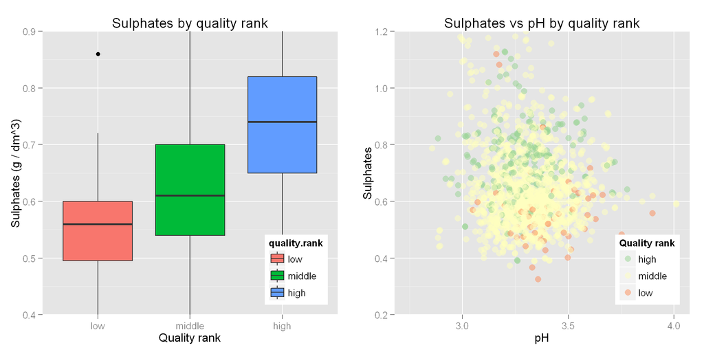

```r
final_plot_two_1 = ggplot( data = rw,
                           aes(x=quality.rank,
                               y = sulphates,
                               fill = quality.rank)) +
  geom_boxplot()+
  xlab("Quality rank")+
  ylab("Sulphates (g / dm^3)")+
  ggtitle("Sulphates by quality rank")+
  coord_cartesian(ylim=c(0.4,0.9))+
  theme(legend.justification=c(1,0),
        legend.position=c(1,0))

final_plot_two_2 = point_plot_func( x_str = "pH",
                 y_str = "sulphates",
                 yl = "Sulphates",
                 xl = "pH",
                 t = "Sulphates vs pH by quality rank")+
  coord_cartesian(ylim=c(0.2,1.2))+
  theme(legend.justification=c(1,0),
        legend.position=c(1,0))

grid.arrange(final_plot_two_1, final_plot_two_2, ncol=2)
```

Quality rank depends on sulphates value and this is unexpected result a little bit . If we look at sulphates vs pH level, we will find HQ wines contain more sulphates at the same level of pH.